# Factor variables in R

Fabian Gülzau

17 Dezember 2017

## Introduction

Until now, we have only discussed factor variables in passing. However, during the last session, some of you encountered issues that made it necessary to encode variables as factors. In the following, I will shorty introduce factor variables and introduce their use with a focus on graphics.

## Factor variables

Wickham and Grolemund [(2017)](http://r4ds.had.co.nz/factors.html) describe the use of factor variables as follows:

> In R, factors are used to work with categorical variables, variables that have a fixed and known set of possible values. They are also useful when you want to display character vectors in a non-alphabetical order.

In many cases, I prefer to leave categorical variables as plain number or character strings until factor encoding is needed. Factors can be created in a ggplot2 function call thus making it easy to create factors on the fly. But let’s see how that is done using some examples.

## Examples: Factor variables

In the following, I will use the Nobel Prize data as an example:

```r
library(tidyverse)
library(ggthemes)
library(scales)
library(RColorBrewer)

nobel <- read.csv(file = "C:\\Users\\User\\HU-Box\\Seafile\\Meine Bibliothek\\Seminare\\WS 2017\\Code\\Nobel Prize\\data\\nobel.csv", stringsAsFactors = FALSE)
```

After some data wrangling with `dplyr`…

```r
nobel.cat.gender <- nobel %>%
  filter(category != "", gender != "org") %>%
  group_by(gender, category) %>%
  summarize(prizes = n()) %>%
  ungroup() %>%
  group_by(category) %>%
  mutate(total = sum(prizes),
         percent = prizes / total * 100)
```

We can use the variables `category` and `gender` which both are categorical to plot the distribution of prizes by category and gender. At first, we use the variables without factor enconding.

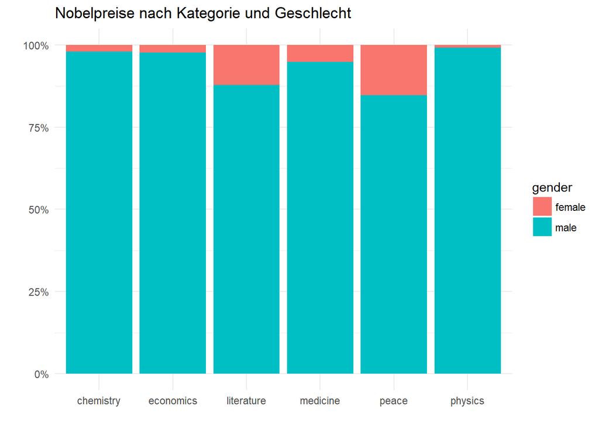

```r
ggplot(data = nobel.cat.gender, mapping = aes(x = category, y = percent, fill = gender)) +
  geom_bar(stat = "identity") +
  scale_y_continuous(labels = function(x) paste0(x, "%")) +
  theme_minimal() +
  labs(title = "Nobelpreise nach Kategorie und Geschlecht",
       x = "",
       y = "")
```

Here, the figure is ordered in alphabetical order of the categories. We can transform the variable `category` as a factor using the function `factor()`.

```r
nobel.cat.gender <- nobel.cat.gender %>%
  ungroup() %>%
  mutate(category.fct = factor(category))

str(nobel.cat.gender$category.fct)
```

```
##  Factor w/ 6 levels "chemistry","economics",..: 1 2 3 4 5 6 1 2 3 4 ...
```

The variable `category.fct` now has six levels which are their names and underlying numeric values. The plot, however, would again be displayed in alphabetical order. Suppose, we want to display the bars in decreasing order of female Nobel laureates. There are two options:

First, we could order the categories manually:

```r
nobel.cat.gender <- nobel.cat.gender %>%
  ungroup() %>%
  mutate(category.fct = factor(category,
                               levels = c("peace", "literature", "medicine", "economics",                                                  "chemistry", "physics"),
                               labels = c("Frieden", "Literatur", "Medizin", "Ökonomie",
                                          "Chemie", "Physik")))
```

The function `factor` has two helpful options: Firstly, `levels` allows us to indicate which categories the variable contains. In addition, the order of levels is the one used in the plot now. Secondly, `labels` can be used to change the text that is displayed.

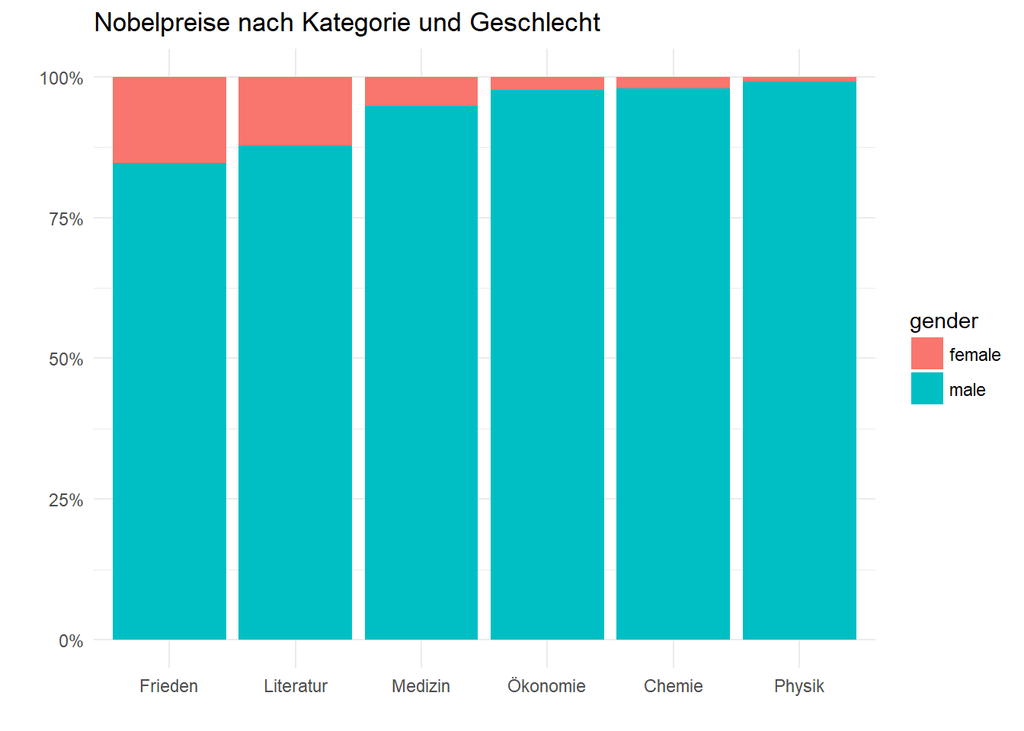

```r
ggplot(data = nobel.cat.gender, mapping = aes(x = category.fct, y = percent, fill = gender)) +
  geom_bar(stat = "identity") +
  scale_y_continuous(labels = function(x) paste0(x, "%")) +
  theme_minimal() +
  labs(title = "Nobelpreise nach Kategorie und Geschlecht",
       x = "",
       y = "")
```

However, manually adjusting the levels is a nuisance. The package `forcats` (part of the tidyverse) allows us to reorder the factor using `fct_reorder`.

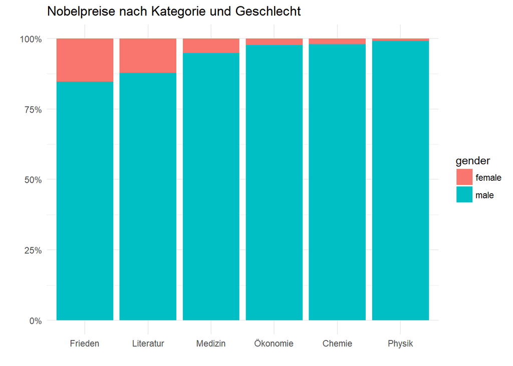

```r
ggplot(data = nobel.cat.gender, mapping = aes(x = fct_reorder(category.fct, x = percent,
                                                              fun = max),
                                              y = percent,
                                              fill = gender)) +
  geom_bar(stat = "identity") +
  scale_y_continuous(labels = function(x) paste0(x, "%")) +
  theme_minimal() +
  labs(title = "Nobelpreise nach Kategorie und Geschlecht",
       x = "",
       y = "")
```

The same approach can be used to put females on the bottom of our bars:

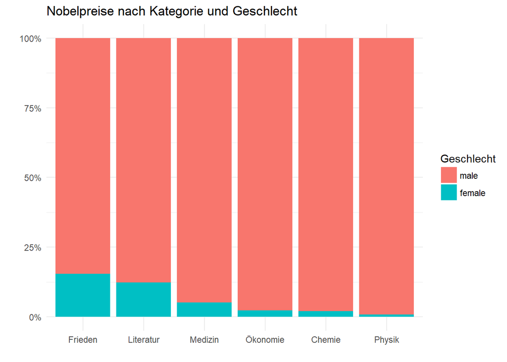

```r
ggplot(data = nobel.cat.gender, mapping = aes(x = fct_reorder(category.fct, x = percent,
                                                              fun = max),
                                              y = percent,
                                              fill = factor(gender, levels = c("male",
                                                                               "female")))) +
  geom_bar(stat = "identity") +
  scale_y_continuous(labels = function(x) paste0(x, "%")) +
  theme_minimal() +
  labs(title = "Nobelpreise nach Kategorie und Geschlecht",
       x = "",
       y = "",
       fill = "Geschlecht")
```

Further, informative readings are [McNamara & Horton (2017)](https://peerj.com/preprints/3163/) and the aforementioned [Wickham & Grolemund (2017)](http://r4ds.had.co.nz/factors.html). Further example are also available [here](http://stat545.com/block029_factors.html).